# Population Ethics via Preference Maps

Formalising graphical representations of distribution-insensitive worlds using indifference curves

2026-06-28

## 0. Background

A philosophy student noticed that the standard graphical representation of the **Repugnant Conclusion** is misleading: shading rectangles under a curve is just a visual trick for multiplying two numbers — it is not actually representing *worlds*. He proposed instead that:

- The **x-axis** = number of people $N$
- The **y-axis** = average happiness $\bar{w}$
- Each **point** $(N, \bar{w})$ represents a possible world

He then drew a downward-sloping straight line, arguing that anything above it is morally better than anything below it.

This document formalises that intuition using the economic tools of **indifference curves** and **utility maximisation**.

### Why His Graph Is an Improvement

The standard illustration of the Repugnant Conclusion computes:

$$V = N \times \bar{w}$$

That is, it shades and compares rectangles. But notice:

> The graph itself isn’t representing worlds. The rectangles are merely a graphical trick for multiplying two numbers.

Your friend’s insight was to make each *point* on the graph represent a possible society — a combination $(N, \bar{w})$. This is precisely how economists represent preferences over bundles of goods.

### The Economic Interpretation

Suppose the moral evaluator has preferences over societies $(N, \bar{w})$. Instead of saying “value equals area,” we simply say there exists some **social welfare function**:

$$W(N, \bar{w})$$

that ranks societies. Every level set

$$W(N, \bar{w}) = c$$

is then an **indifference curve** — exactly as in consumer theory.

### Indifference Curves for Different Ethical Theories

#### Total Utilitarianism

$$W = N \cdot \bar{w}$$

The level sets are:

$$N \cdot \bar{w} = c \implies \bar{w} =
\frac{c}{N}$$

These are **downward-sloping hyperbolas** — familiar to any economist as standard indifference curves. They tell you exactly how much average welfare you are willing to sacrifice in exchange for additional people.

#### Average Utilitarianism

$$W = \bar{w}$$

The level sets are **horizontal lines**. Population size is entirely irrelevant to moral value.

#### Critical-Level Utilitarianism

$$W = N(\bar{w} - c)$$

where $c > 0$ is the critical welfare level. The level sets are again hyperbolas, but shifted — a life is only worth adding if welfare exceeds the threshold $c$.

### Lexical and Rights-Based Views

These generate **kinked or L-shaped indifference curves**, possibly with vertical sections or asymptotes — but economists already know how to interpret such geometries.

### What Your Friend Drew

A **downward-sloping straight line** is a single linear indifference curve:

$$\bar{w} = a - bN \quad (a, b >
0)$$

This implicitly says:

- There *is* a trade-off between quantity and quality of life.
- The trade-off is **constant**: each additional person always costs the same amount of average welfare.

Once indifference curves are introduced, he will realise there are *infinitely many* such curves — one for each level of moral value. The **entire ethical theory** is just the family of curves. This gives philosophers a much richer language:

| Curve shape | Ethical implication |
| --- | --- |
| **Hyperbolas** | Total utilitarianism |
| **Straight lines** | Constant trade-off (what your friend drew) |
| **Convex curves** | Diminishing marginal moral value of additional people |
| **Kinked curves** | Threshold views |
| **Vertical asymptotes** | Rights-based theories |
| **Non-convex curves** | Multiple moral regimes |

### The Marginal Rate of Substitution

This is where economics becomes especially powerful. The slope of an indifference curve is:

$$\text{MRS} = -\frac{\partial W /
\partial N}{\partial W / \partial \bar{w}}$$

Translated into philosophy, this answers:

> *How much average welfare would we be willing to sacrifice in order to create one additional person while remaining morally indifferent?*

That is an incredibly natural philosophical question. Instead of vague talk about “trade-offs,” we get a **precise local concept**. It also clarifies where disagreement between ethical views actually lies:

- One theorist thinks additional people become **less valuable** as population grows → MRS falls in magnitude as $N$ increases (convex curves).
- Another thinks additional people remain **equally valuable** → constant MRS (straight lines).
- Another insists there is a **minimum acceptable welfare level** → critical-level utilitarianism.

All of these become different geometries.

### What Economics Adds

Economics separates two things that population ethicists often conflate:

1. The **representation of preferences** — the shape of indifference curves.
2. The **axioms generating them** — completeness, transitivity, continuity, and so on.

Population ethicists often jump straight to candidate social welfare functions (Total, Average, Critical-Level) without first exploiting this geometric framework. The indifference-curve approach reframes the question from:

> *Which formula computes value?*

to:

> *What shape should the indifference curves have?*

That is a much deeper question.

### One Important Caveat

A point $(N, \bar{w})$ does **not** uniquely identify a world. Two societies could have identical population and identical average welfare but very different *distributions* of welfare — for example:

- Everyone equally happy, or
- Half ecstatic and half miserable.

This diagram implicitly assumes that only average welfare and population size matter. That is consistent with many discussions of the Repugnant Conclusion, but it **abstracts away** from inequality, prioritarianism, and other distribution-sensitive views. Including those would require additional dimensions or a richer state space.

### Summary: A Suggested Order of Exposition

For a philosopher who is new to economics but already thinking graphically, the ideas can be introduced in this order:

1. A society is a point $(N, \bar{w})$.
2. A moral theory is a **preference ordering** over those points.
3. **Indifference curves** represent equally good societies.
4. Different ethical theories correspond to different **families of curves**.
5. The **slope** of a curve gives the local trade-off between additional people and higher average welfare (the MRS).

This progression is likely to feel very natural to someone already thinking graphically about population ethics, and it provides a common language in which economists and philosophers can productively engage.

## 1. Preferences Maps

### Worlds as bundles

In standard consumer theory, the object of choice is a *consumption bundle* $(x_1, x_2)$. Here the object is a **world**:

$$w = (N,\, \bar{u}), \quad N > 0,\;
\bar{u} > 0$$

where $N$ is population size (treated as continuous) and $\bar{u}$ is average welfare. Every point in the positive quadrant of the $(N, \bar{u})$ plane is a possible world.

> **Scope limitation.** This representation discards *distributional* information: two worlds with the same $(N, \bar{u})$ but different welfare distributions are treated as identical. The framework below applies only to *distribution-insensitive* ethical theories.

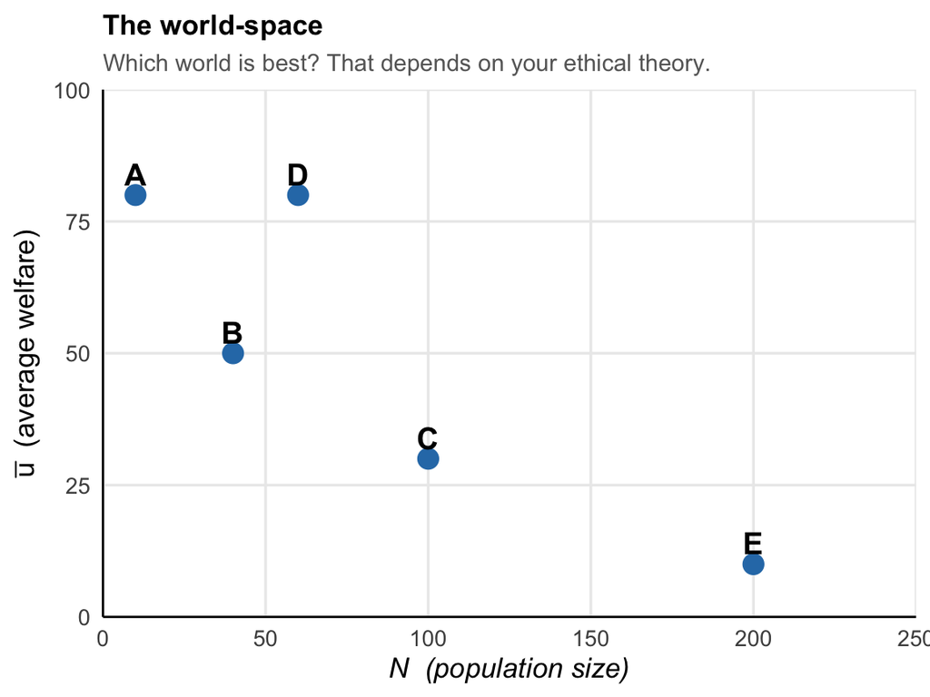

Each dot is a world (N, ū). We want to rank them.

### Preference relations

Given two worlds $w = (N, \bar{u})$ and $w' = (N', \bar{u}')$, a moral agent holds one of three relations:

| Relation | Symbol | Meaning |
| --- | --- | --- |
| Strict preference | $w \succ w'$ | $w$ is strictly better than $w'$ |
| Indifference | $w \sim w'$ | $w$ and $w'$ are equally good |
| Weak preference | $w \succsim w'$ | $w$ is at least as good as $w'$ |

These are linked: $w \succsim w'$ and $w' \succsim w$ together imply $w \sim w'$; $w \succsim w'$ but not $w' \succsim w$ implies $w \succ w'$.

### Preference as revealed through choice behaviour

In consumer theory, preferences are operational: $(x_1, x_2) \succ (y_1, y_2)$ means the consumer *chooses* $(x_1, x_2)$ when both are available.

In population ethics the analogue is *hypothetical choice*: $w \succ w'$ means you would choose to bring world $w$ into existence rather than $w'$. Preferences can be elicited through policy deliberation, willingness-to-fund studies, or philosophical thought experiments.

## 2 Assumptions about Preferences

### Why axioms are imposed

Without restrictions, $\succsim$ can be arbitrary — cyclical, incomplete, or discontinuous. Axioms are *normative hypotheses* about rational ethical judgment. Some population-ethics intuitions violate them (e.g. Parfit’s *Mere Addition Paradox* troubles transitivity).

### Completeness

For any $w, w'$: $\;w \succsim w'$ or $w' \succsim w$ (or both).

Every pair of worlds is comparable. **Ethical price:** you cannot declare two worlds incommensurable — e.g. refuse to rank “10 billion people at barely positive welfare” against “1 million at very high welfare.”

### Reflexivity

$w \succsim w$ for all $w$. Trivial: every world is at least as good as itself.

### Transitivity

If $w \succsim w'$ and $w' \succsim w''$, then $w \succsim w''$. No preference cycles.

**Ethical price:** some sequences of pairwise reasonable judgments lead to cycles in population ethics. Transitivity rules these out by fiat.

### Existence of a “best” world

Transitivity is *necessary* for a most-preferred world to exist in any finite set. Without it, $w_A \succ w_B \succ w_C \succ w_A$ gives a cycle — no world is best. Completeness + transitivity together guarantee a best element in every finite set.

## 3 Indifference Curves

### Weakly preferred sets

Fix a world $w_0 = (N_0, \bar{u}_0)$. The **weakly preferred set** is:

$$P(w_0) = \{(N, \bar{u}) : (N, \bar{u})
\succsim w_0\}$$

Its boundary — worlds *equally good* as $w_0$ — is the **indifference curve** through $w_0$.

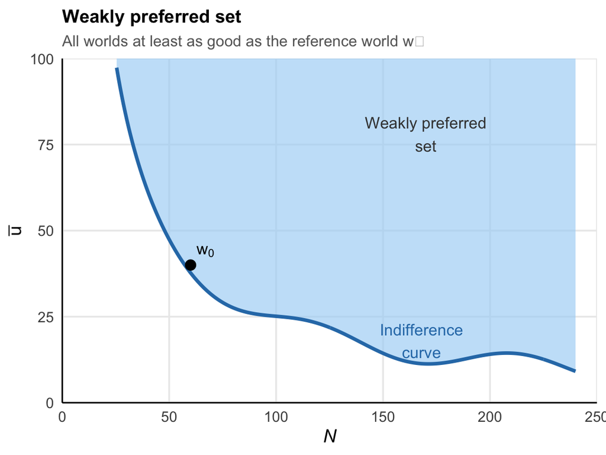

Shaded: weakly preferred set. Boundary = indifference curve through w₀.

### Construction of indifference curves

Start at $(N_0, \bar{u}_0)$. Increase $N$ by $\Delta N$; ask how much $\bar{u}$ must *decrease* to restore indifference. Repeat to trace the curve. The answer at each step is the MRS (§6.).

### Why indifference curves cannot cross

**Claim:** Two distinct indifference curves cannot intersect.

**Proof.** Suppose curves $C_1 \neq C_2$ cross at $Z$. Take $X \in C_1 \setminus C_2$ and $Y \in C_2 \setminus C_1$.

- $X, Z$ both on $C_1$: $X \sim Z$
- $Y, Z$ both on $C_2$: $Y \sim Z$
- Transitivity: $X \sim Y$

But $C_1 \neq C_2$ means $X$ and $Y$ represent *different* welfare levels — contradiction. $\square$

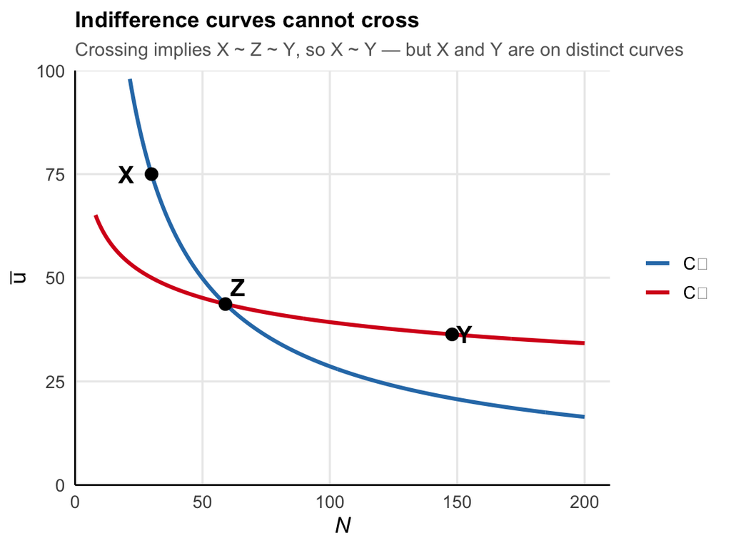

If the curves crossed at Z then X ~ Z ~ Y implies X ~ Y — contradicting distinct welfare levels.

### Relationship between preferences and the indifference map

The **indifference map** — the full collection of curves — partitions the $(N, \bar{u})$ plane. Every world lies on exactly one curve. Moving to a higher curve (under monotonicity) means a strictly preferred world.

## 4. Examples of Preferences

### Perfect Substitutes

$$W(N, \bar{u}) = aN +
b\bar{u}$$

You are always willing to exchange $a/b$ units of $\bar{u}$ for one extra person at a **constant rate**, regardless of current levels. Indifference curves are **parallel straight lines** with slope $-a/b$.

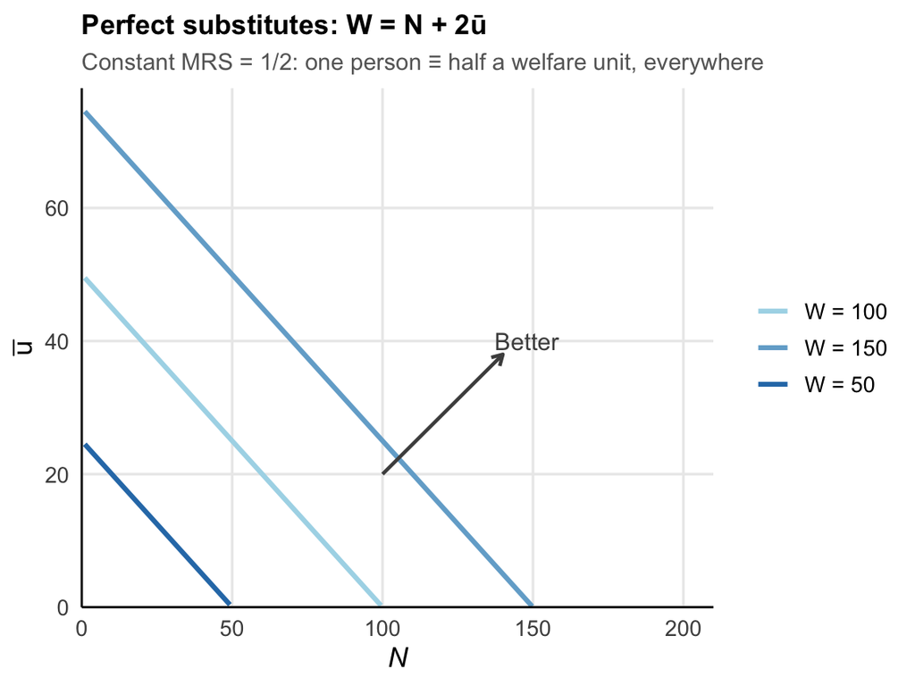

Perfect substitutes (W = N + 2ū): constant trade-off. Parallel lines, slope = −1/2.

**Ethical content.** The marginal value of an extra person (in welfare units) is constant — independent of how many people exist or how well-off they are.

### Perfect Complements

$$W(N, \bar{u}) =
\min\!\left\{\frac{N}{a},\, \frac{\bar{u}}{b}\right\}$$

Population and welfare are only valuable *together*, in fixed proportion $a:b$. Extra population without proportional welfare improvement adds nothing (and vice versa). Indifference curves are **L-shaped**, with kinks along the ray $\bar{u} = (b/a)N$.

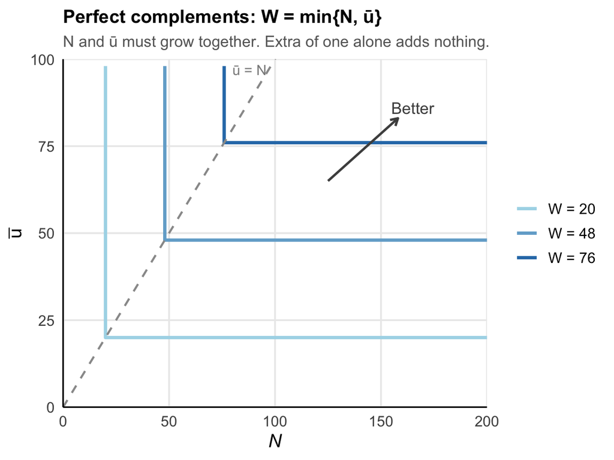

Perfect complements (W = min{N, ū}): L-shaped curves. Kinks along the diagonal ū = N.

**Ethical content.** More people is worthless without proportional welfare (and vice versa). Scale and quality are inseparable requirements of a valuable world.

### Bads

A **bad** is a quantity the agent *dislikes* — more is worse. In population ethics this can arise when the axes are reinterpreted:

- **$N$ = number of deaths**: more deaths is bad. To stay indifferent while deaths increase, welfare must rise to compensate. Indifference curves slope **upward** (positive slope).
- **$\bar{u}$ = average suffering**: more suffering is bad.

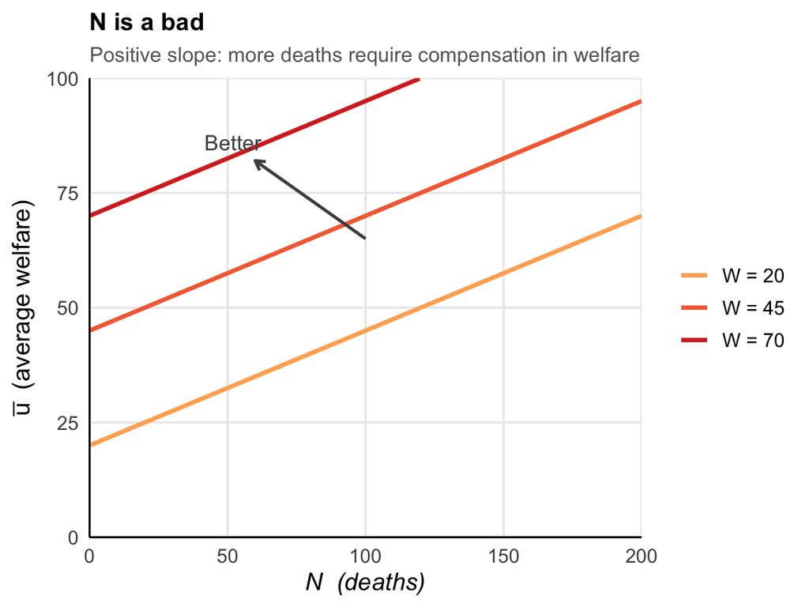

N is a bad (deaths). More deaths require higher welfare to compensate. Curves slope upward; preferred direction is north-west.

### Vertical indifference curves

A dimension is **neutral** when the agent is completely indifferent to changes in it. Two cases arise in population ethics:

- **$N$ is neutral** (only $\bar{u}$ matters): worlds with the same $\bar{u}$ are equally good regardless of $N$. Indifference curves are **horizontal lines**. This is *average utilitarianism* ($W = \bar{u}$).
- **$\bar{u}$ is neutral** (only $N$ matters): worlds with the same $N$ are equally good regardless of $\bar{u}$. Indifference curves are **vertical lines**. This is *pure headcount* ($W = N$).

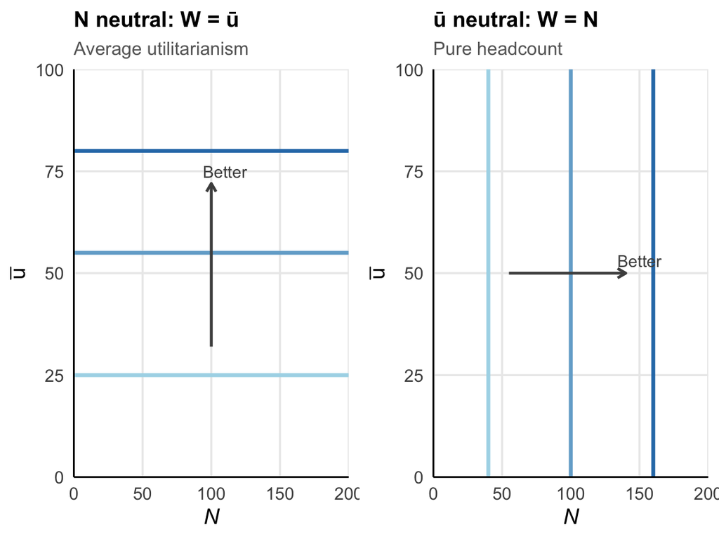

Left: N is neutral (average utilitarianism, W = ū) — horizontal curves. Right: ū is neutral (pure headcount, W = N) — vertical curves.

### Satiation

There exists an **ideal world** $(N^*, \bar{u}^*)$ — a *bliss point*. Worlds further from it are worse. Beyond the bliss point, $N$ and $\bar{u}$ each become bads. Indifference curves are **closed ovals** around the bliss point; inner ovals are strictly preferred to outer ones.

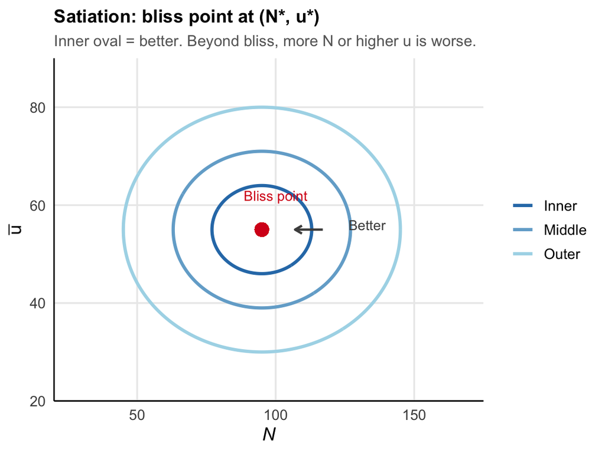

Satiation: bliss point (red dot). Indifference curves are concentric ellipses. Inner oval = better.

Beyond the bliss point, indifference curves acquire a *positive* slope (in the regions where only one dimension has been “satiated”) and curve back to form closed ovals.

## 5. Well-Behaved Preferences

We now impose two axioms that characterise the *standard* case where $N$ and $\bar{u}$ are both genuine goods.

### Monotonicity

**Definition.** If $N' \geq N$ and $\bar{u}' \geq \bar{u}$ with at least one strict inequality, then $(N', \bar{u}') \succ (N, \bar{u})$.

**Ethical content.** Both population size and average welfare are genuine goods — more of either strictly improves the world. Monotonicity rules out satiation and the view that $N$ is ethically neutral.

**Implication.** Monotonicity $\Rightarrow$ indifference curves have **negative slope**. Moving north-east from any point reaches a strictly better world; to stay equally good when moving right, you must move down.

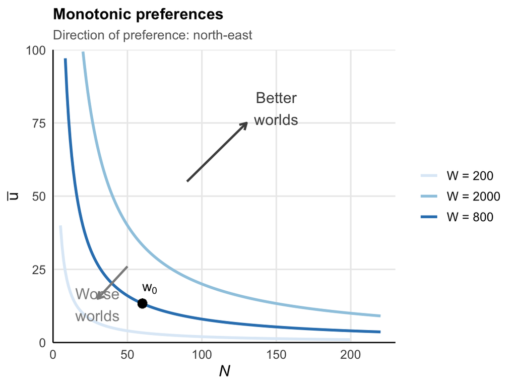

Monotonic preferences: direction of preference is north-east. Curves slope downward.

### Convexity

**Definition.** For any $w \sim w'$, the blend $w_t = tw + (1-t)w'$ satisfies $w_t \succsim w$ for all $t \in [0,1]$.

**Ethical content.** *Balanced worlds are preferred to extremes.* Given two equally-good worlds — one with large $N$ and low $\bar{u}$, another with small $N$ and high $\bar{u}$ — any blend is at least as good.

**Implication.** The weakly preferred set $P(w_0)$ is **convex**; indifference curves are **bowed inward** toward the origin. Any chord connecting two equally-good worlds lies *above* the curve.

**Strict convexity** requires $w_t \succ w$ for $t \in (0,1)$ — no flat segments. This guarantees a unique most-preferred world when a constraint is imposed.

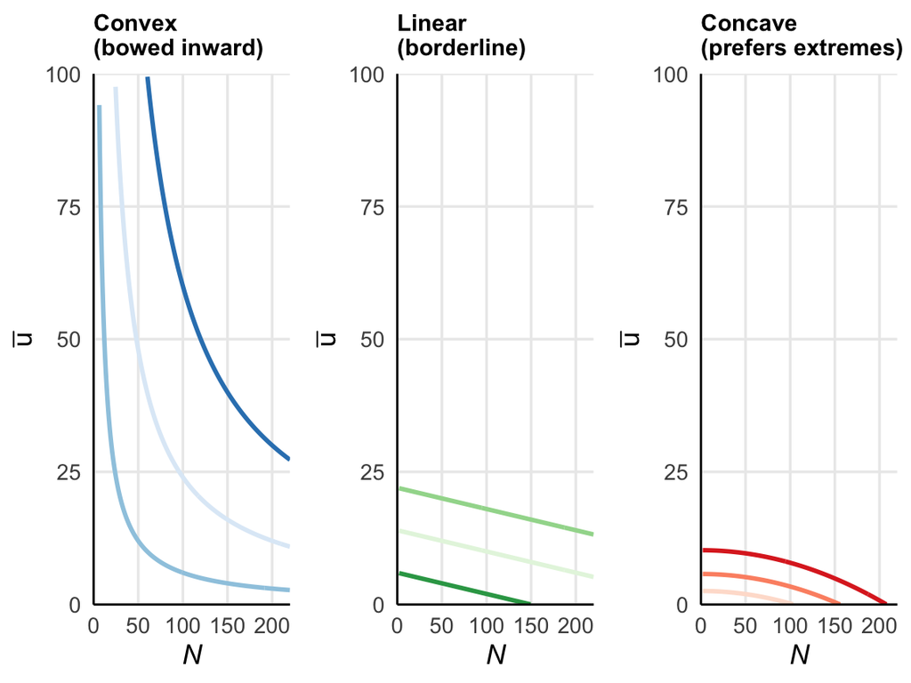

Three preference geometries. Convex (left): averages preferred to extremes, curves bow inward. Concave (right): extremes preferred.

## 6. The Marginal Rate of Substitution (MRS)

### Definition and slope of the indifference curve

The **MRS** at $(N, \bar{u})$ is the absolute slope of the indifference curve at that point:

$$\text{MRS}(N, \bar{u}) \;=\;
-\frac{d\bar{u}}{dN}\bigg|_{W = \text{const}} \;=\; \frac{\partial
W/\partial N}{\partial W/\partial \bar{u}} \;>\; 0$$

It is the amount of average welfare you are willing to *give up* in exchange for one additional person while remaining on the same indifference curve.

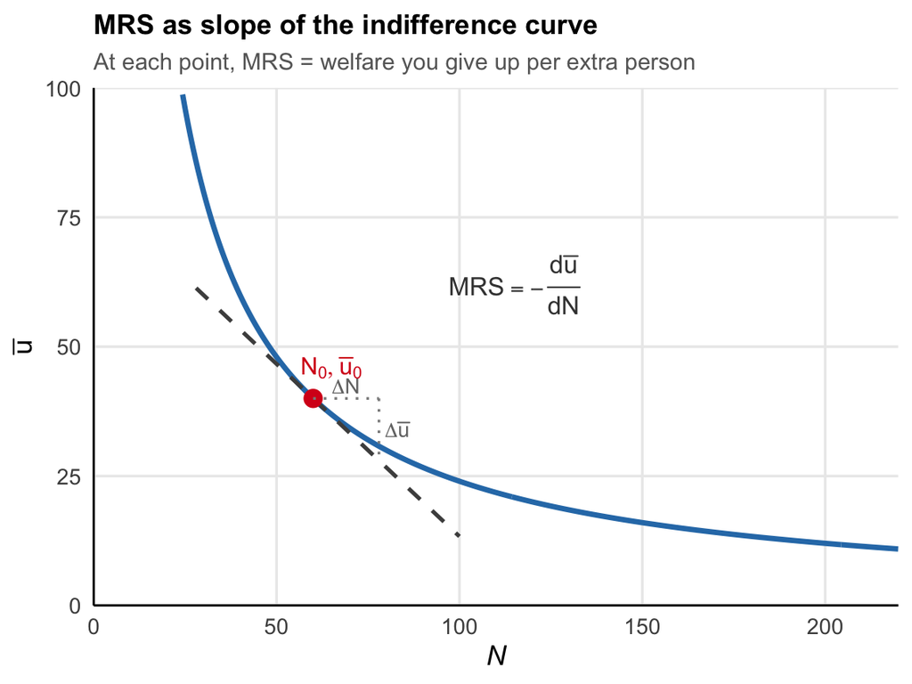

MRS = |slope| of the indifference curve at (N₀, ū₀). Tangent line shown dashed.

### Marginal substitution interpretation

[output not shown]

Under **convex preferences**, MRS *decreases* as $N$ increases along a curve — **diminishing MRS**. The more people there already are, the less you value one more at the margin.

### Exchange interpretation and tangency condition

Suppose population can be “traded” for welfare at a fixed **exchange rate** $E$: gaining $\Delta N$ extra people costs $E \cdot \Delta N$ units of $\bar{u}$. The achievable trades from $(N_0, \bar{u}_0)$ lie on a line through $(N_0, \bar{u}_0)$ with slope $-E$.

- If $E < \text{MRS}$: trading at rate $E$ is a good deal — moves to a better indifference curve.
- If $E > \text{MRS}$: trading is too costly — moves to a worse curve.
- If $E = \text{MRS}$: **tangency condition** — the exchange line just touches the curve. This is the locally optimal point; no trade improves welfare.

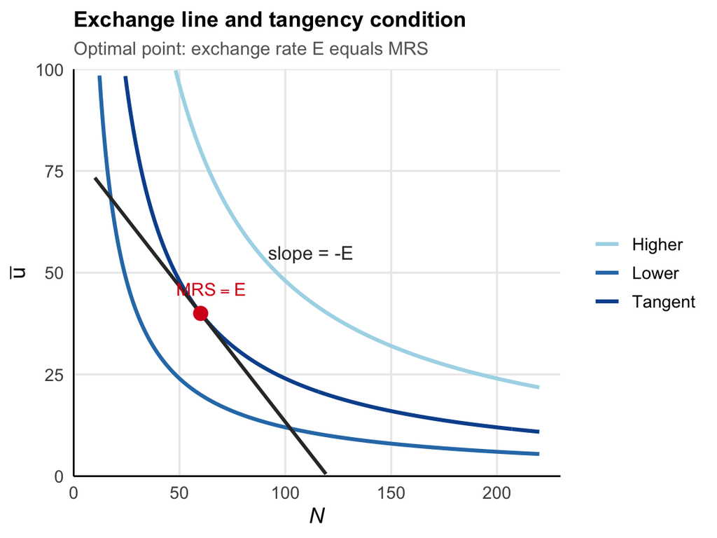

Exchange line with slope −E tangent to the indifference curve. At the tangency point, E = MRS — no trade improves welfare.

## 7. Special case: the Repugnant Conclusion

Parfit’s **Repugnant Conclusion** (RC): under total utilitarianism, for any world $A$ with large $N$ and high $\bar{u}$, there exists a world $Z$ with a *vastly* larger $N$ and $\bar{u}$ *barely above zero* that is ethically *better*.

### Total utilitarianism

$$W(N, \bar{u}) = N \cdot \bar{u}, \quad
\text{MRS} = \frac{\bar{u}}{N}$$

Indifference curves are **rectangular hyperbolae**: $\bar{u} = c/N$. As $N \to \infty$, MRS $\to 0$: you need only an infinitesimal $\bar{u}$ drop to accept one more person. The hyperbolae sweep arbitrarily close to $\bar{u} = 0$, making the RC **geometrically inevitable**.

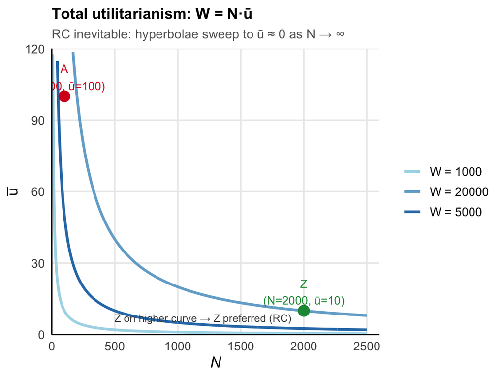

Total utilitarianism. Z (huge pop, tiny welfare) lies on a higher curve than A. The RC is unavoidable.

### The utility monster: the same problem in reverse

Nozick’s **utility monster** (1974) is a being that converts resources into welfare far more efficiently than ordinary people. Under total utilitarianism, you should give it everything.

In the original form, this is a *distribution* problem within a fixed population, and the $(N, \bar{u})$ framework **hides it**: since $\bar{u}$ is already an average, a world where one person has welfare $10^6$ and everyone else has welfare $0$ looks identical to a world with even distribution, provided the mean is the same.

There is, however, a **population-ethics analog** that is directly representable — *should we create one super-happy being rather than many ordinarily happy people?* Under $W = N\bar{u}$:

$$W_M = 1 \times 2000 = 2000 \quad >
\quad W_B = 100 \times 10 = 1000 \quad \Rightarrow \quad M \succ
B$$

The monster-world $M = (1, 2000)$ beats the balanced world $B = (100, 10)$ because it lies on a *higher* hyperbola.

This is **geometrically symmetric with the RC**:

| Problem | Direction on plane | Mechanism |
| --- | --- | --- |
| Repugnant Conclusion | Lower-right (more $N$, less $\bar{u}$) | Higher hyperbola reachable with huge $N$ and tiny $\bar{u}$ |
| Utility monster | Upper-left (less $N$, more $\bar{u}$) | Higher hyperbola reachable with $N=1$ and enormous $\bar{u}$ |

Both are possible for the same reason: rectangular hyperbolae extend without bound in **both** directions. Unlimited substitution between $N$ and $\bar{u}$ is always available.

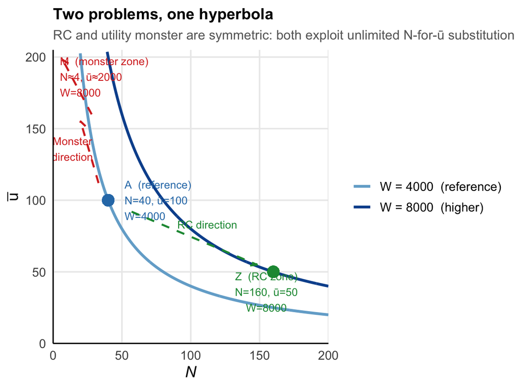

RC and utility monster are mirror images. A (reference) sits on W = 4000. Both Z (RC direction) and M (monster direction) sit on the higher curve W = 8000 — and are equally good as each other under total utilitarianism.

### What indifference maps avoid the RC?

To avoid the RC, no indifference curve may dip arbitrarily close to $\bar{u} = 0$.

**Average utilitarianism:** $W = \bar{u}$ — **horizontal lines**. Avoids RC completely; $N$ is neutral (violates monotonicity in $N$).

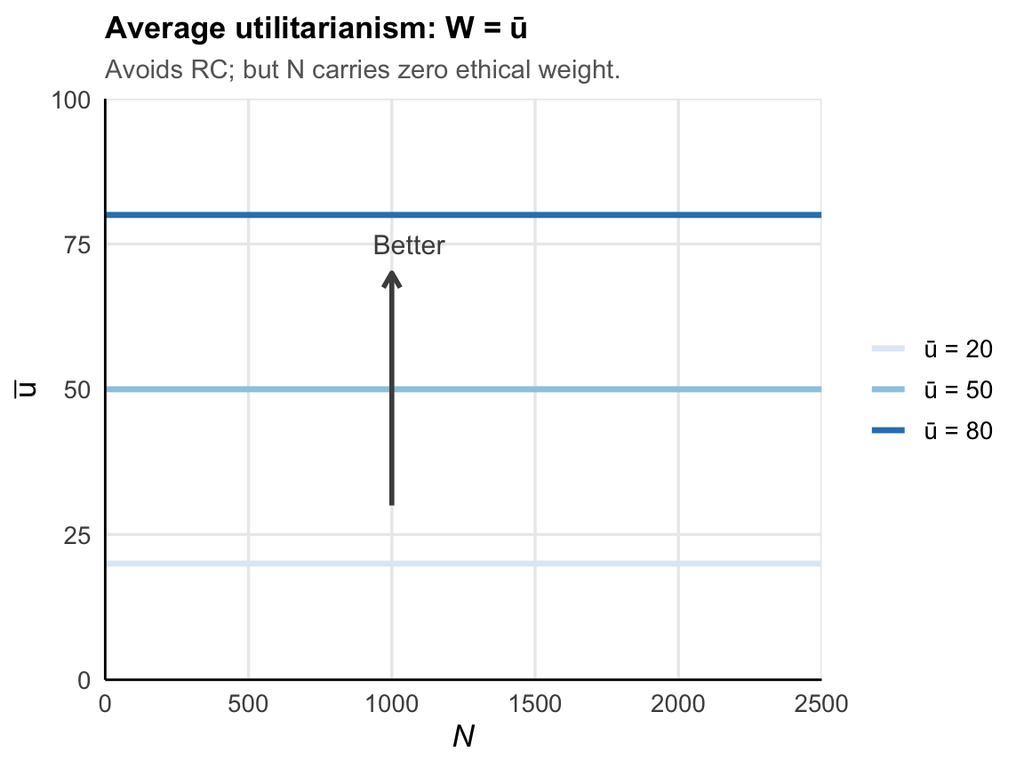

Average utilitarianism: horizontal IC. Population size carries zero weight.

**Critical-level utilitarianism:** $W = N(\bar{u} - \alpha)$, $\alpha > 0$. Adding a person is good only if their welfare exceeds $\alpha$. Indifference curves are **shifted hyperbolae** with horizontal asymptote at $\bar{u} = \alpha$. No curve dips below $\alpha$, so the RC is avoided.

$$\bar{u} = \alpha +
\frac{c}{N}$$

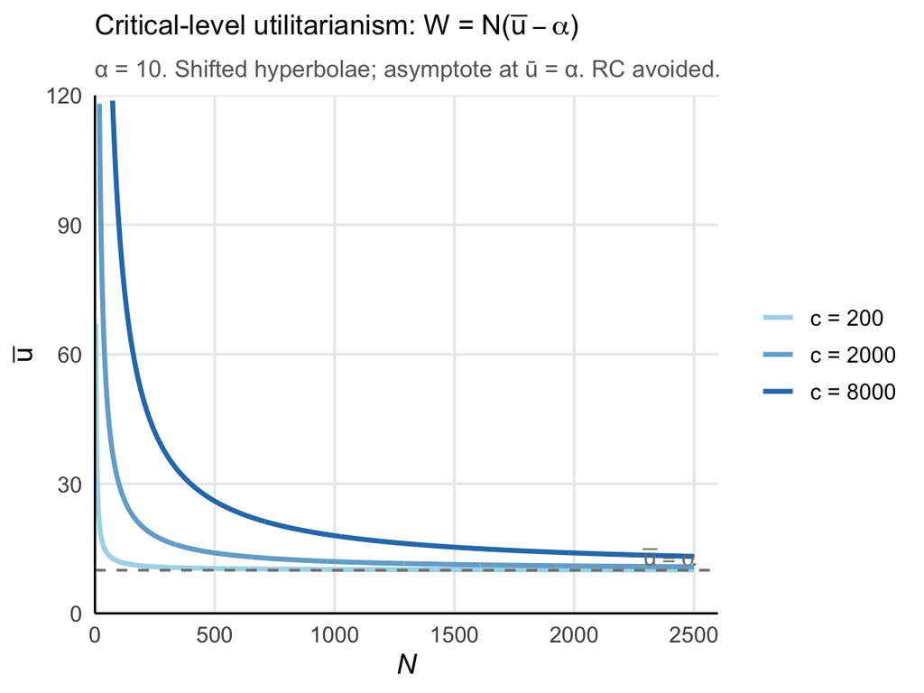

Critical-level utilitarianism (α = 10). Curves cannot dip below ū = α. RC avoided.

## 8.When $N$ or $\bar{u}$ are bads

The framework accommodates reinterpretations of the axes.

**$N$ = number of deaths**: preferred direction is *north-west*; curves slope upward. More deaths requires higher welfare to compensate.

**Both are bads** (e.g. $N$ = deaths, $\bar{u}$ = average disutility): preferred direction is *south-west*; curves slope downward again but preference reverses.

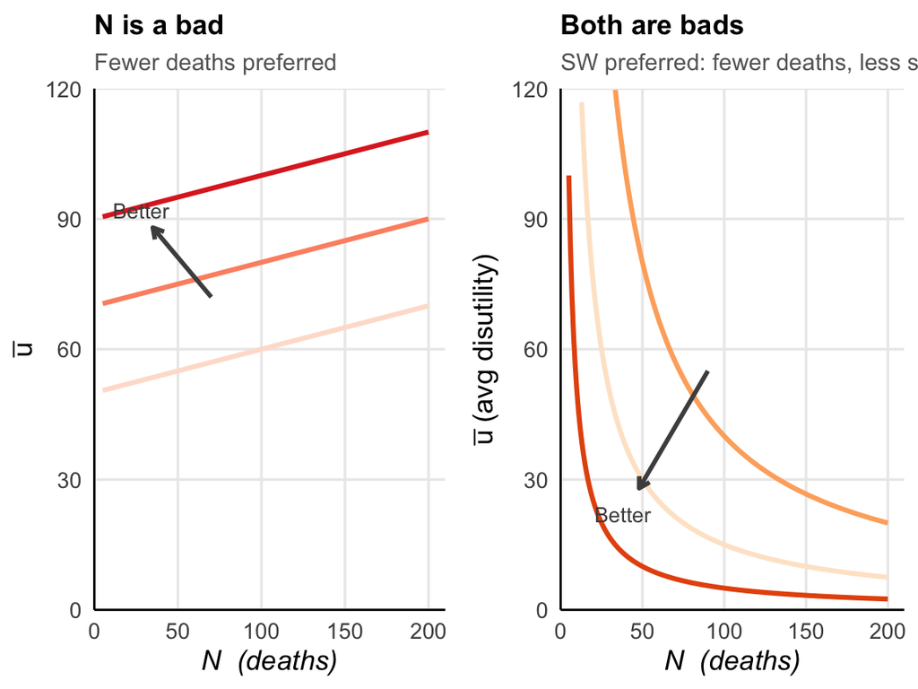

Left: N is a bad (deaths). Right: both N and ū are bads. Preferred direction shown by arrow.

## 9. Summary tables

### Axioms → curve properties

| Axiom | Statement | Ethical price | Curve property |
| --- | --- | --- | --- |
| **Completeness** | Any $w, w'$ are comparable | No incommensurable pairs allowed | Curves **partition** the plane |
| **Reflexivity** | $w \succsim w$ | Trivial | Every world lies on its own curve |
| **Transitivity** | No cycles | Spectrum arguments may violate it | Distinct curves **cannot cross** |
| **Continuity** | No ethical cliffs | Rules out lexicographic priorities | Curves are **smooth** |
| **Monotonicity** | More $N$ and $\bar{u}$ both better | Excludes satiation; $N$ must be a good | Curves have **negative slope** |
| **Convexity** | Averages preferred to extremes | Balance is a substantive assumption | Curves **bow inward**; MRS decreasing |

### Ethical theories as special cases

| Theory | $W(N, \bar{u})$ | Curve shape | RC? | Monotone in $N$? |
| --- | --- | --- | --- | --- |
| Total utilitarianism | $N\bar{u}$ | Rectangular hyperbolae | **Yes** | Yes |
| Average utilitarianism | $\bar{u}$ | Horizontal lines | No | **No** |
| Critical-level ($\alpha > 0$) | $N(\bar{u} - \alpha)$ | Shifted hyperbolae | No | Yes (above $\alpha$) |
| Perfect substitutes | $aN + b\bar{u}$ | Parallel lines | Depends on $a, b$ | Yes |
| Perfect complements | $\min\{N/a, \bar{u}/b\}$ | L-shaped | Depends | Yes |
| Satiation | — | Concentric ovals | No | **No** (beyond bliss) |

### Examples of preferences: curve-shape summary

| Preference type | $W$ example | Curve shape | MRS |
| --- | --- | --- | --- |
| Perfect substitutes | $N + 2\bar{u}$ | Parallel straight lines | Constant |
| Perfect complements | $\min\{N, \bar{u}\}$ | L-shaped (kinks on diagonal) | 0 or $\infty$ |
| Bads ($N$ = deaths) | $\bar{u} - 0.25N$ | Upward-sloping | Negative (positive slope) |
| $N$ neutral | $\bar{u}$ | Horizontal lines | $0$ |
| $\bar{u}$ neutral | $N$ | Vertical lines | $\infty$ |
| Satiation | — | Closed ovals around $(N^*, \bar{u}^*)$ | Changes sign beyond bliss |
| Well-behaved | $N\bar{u}$ | Convex hyperbolae | $\bar{u}/N$ (decreasing in $N$) |

*Compiled with R 4.5.2. Plots: `ggplot2`, `gridExtra`.*